# Project 4: Analyzing TMDb movie data

```python
# Exploring non numerical values
# columns: original_title, cast, director, keywords, overview, genres, production_companies
```

```python
# keywords
display(df["keywords"].head())
display(len(df["keywords"]))
display(df["keywords"].str.count("|"))
```

```
0    monster|dna|tyrannosaurus rex|velociraptor|island
1     future|chase|post-apocalyptic|dystopia|australia
2    based on novel|revolution|dystopia|sequel|dyst...
3                android|spaceship|jedi|space opera|3d
4                  car race|speed|revenge|suspense|car
Name: keywords, dtype: object
```

```
10866
```

```
0        50.0
1        49.0
2        58.0
3        38.0
4        36.0
         ...
10861    25.0
10862    26.0
10863    25.0
10864     6.0
10865    36.0
Name: keywords, Length: 10866, dtype: float64
```

```python
# overview
display(df["overview"].head())
display(len(df["overview"]))
display(df["overview"].str.count("|"))
```

```
0    Twenty-two years after the events of Jurassic ...
1    An apocalyptic story set in the furthest reach...
2    Beatrice Prior must confront her inner demons ...
3    Thirty years after defeating the Galactic Empi...
4    Deckard Shaw seeks revenge against Dominic Tor...
Name: overview, dtype: object
```

```
10866
```

```
0        176.0
1        582.0
2        140.0
3        146.0
4         92.0
         ...
10861    324.0
10862    227.0
10863    238.0
10864    200.0
10865    144.0
Name: overview, Length: 10866, dtype: float64
```

```python
# original_title
display(df["original_title"].head())
display(len(df["original_title"]))
display(df["original_title"].str.count("|"))
```

```
0                  Jurassic World
1              Mad Max: Fury Road
2                       Insurgent
3    Star Wars: The Force Awakens
4                       Furious 7
Name: original_title, dtype: object
```

```
10866
```

```
0        15
1        19
2        10
3        29
4        10
         ..
10861    19
10862    11
10863    20
10864    23
10865    25
Name: original_title, Length: 10866, dtype: int64
```

```python
# cast
display(df["cast"].head())
display(len(df["cast"]))
display(df["cast"].str.count("|"))
```

```
0    Chris Pratt|Bryce Dallas Howard|Irrfan Khan|Vi...
1    Tom Hardy|Charlize Theron|Hugh Keays-Byrne|Nic...
2    Shailene Woodley|Theo James|Kate Winslet|Ansel...
3    Harrison Ford|Mark Hamill|Carrie Fisher|Adam D...
4    Vin Diesel|Paul Walker|Jason Statham|Michelle ...
Name: cast, dtype: object
```

```
10866
```

```
0        76.0
1        70.0
2        67.0
3        65.0
4        71.0
         ...
10861    79.0
10862    71.0
10863    89.0
10864    73.0
10865    73.0
Name: cast, Length: 10866, dtype: float64
```

```python
# director
display(df["director"].head())
display(len(df["director"]))
display(df["director"].str.count("|"))
```

```
0     Colin Trevorrow
1       George Miller
2    Robert Schwentke
3         J.J. Abrams
4           James Wan
Name: director, dtype: object
```

```
10866
```

```
0        16.0
1        14.0
2        17.0
3        12.0
4        10.0
         ...
10861    12.0
10862    19.0
10863    15.0
10864    12.0
10865    17.0
Name: director, Length: 10866, dtype: float64
```

```python
# genres
display(df["genres"].head())
display(len(df["genres"]))
display(df["genres"].str.count("|"))
```

```
0    Action|Adventure|Science Fiction|Thriller
1    Action|Adventure|Science Fiction|Thriller
2           Adventure|Science Fiction|Thriller
3     Action|Adventure|Science Fiction|Fantasy
4                        Action|Crime|Thriller
Name: genres, dtype: object
```

```
10866
```

```
0        42.0
1        42.0
2        35.0
3        41.0
4        22.0
         ...
10861    12.0
10862    23.0
10863    15.0
10864    14.0
10865     7.0
Name: genres, Length: 10866, dtype: float64
```

```python
# production_companies
display(df["production_companies"].head())
display(len(df["production_companies"]))
display(df["production_companies"].str.count("|"))
```

```
0    Universal Studios|Amblin Entertainment|Legenda...
1    Village Roadshow Pictures|Kennedy Miller Produ...
2    Summit Entertainment|Mandeville Films|Red Wago...
3            Lucasfilm|Truenorth Productions|Bad Robot
4    Universal Pictures|Original Film|Media Rights ...
Name: production_companies, dtype: object
```

```
10866
```

```
0        89.0
1        53.0
2        70.0
3        42.0
4        76.0
         ...
10861    18.0
10862    66.0
10863     8.0
10864    24.0
10865    10.0
Name: production_companies, Length: 10866, dtype: float64
```

**Analysis of non numerical columns**

- As analyzed when I inspected the first row: "cast", "genres" and "production_companies" column have a list of elements separated by "|". So I will need to to separate them for answering questions related to a certain cas member, genre or production company.
- All the text information are declared as object, so I will need to convert it to string

```python
## Exploring special cases: release_year and release_date
### let's check with more details the release_date values
display(df["release_date"].value_counts())
display(df["release_date"].describe())
display(df["release_date"].sort_values())
```

```
1/1/09      28
1/1/08      21
1/1/07      18
1/1/05      16
10/10/14    15
            ..
3/2/65       1
12/15/94     1
12/1/61      1
1/3/70       1
10/1/82      1
Name: release_date, Length: 5909, dtype: int64
```

```
count      10866
unique      5909
top       1/1/09
freq          28
Name: release_date, dtype: object
```

```
8880     1/1/00
8875     1/1/00
8865     1/1/00
8839     1/1/00
8831     1/1/00
          ...
10246    9/9/93
4341     9/9/94
8530     9/9/96
5300     9/9/97
5335     9/9/97
Name: release_date, Length: 10866, dtype: object
```

```
count    10866.000000
mean      2001.322658
std         12.812941
min       1960.000000
25%       1995.000000
50%       2006.000000
75%       2011.000000
max       2015.000000
Name: release_year, dtype: float64
```

```
2015    629
2014    700
2013    659
2012    588
2011    540
2010    490
2009    533
2008    496
2007    438
2006    408
2005    364
2004    307
2003    281
2002    266
2001    242
```

[output cut: 42 more lines]

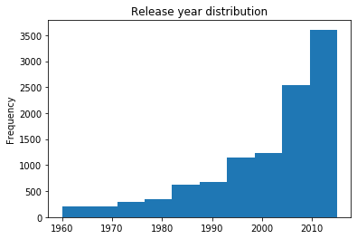

```python
### let's check with more details the release_year values

display(df["release_year"].describe())
display(df["release_year"].value_counts().sort_index(ascending=False))
df["release_year"].plot.hist(title="Release year distribution")
```

**Analysis**

- We can see that "release_dates" like 1/1/00, need the year digits to be converted from "00" to "2000" before converting this column to datetime type.
- Since we do not have questions that need the complete date, only the year, this conversion will be left to the last part of this report (if needed).
- To answer questions that need "year", I will use "release_year" column which is skewed left.
- It seems a priori that there are more movies released now than in the early years!!

### Data Cleaning

#### Structure and problems that need to be corrected discussion

1. Removing columns: There are columns that do not add information for this analysis: "id", "imdb_id", "homepage","tagline", "overview", "budget_adj", "revenue_adj" and "release_date". These will be dropped
2. Dropping duplicated values: There is to check if there are duplicated values. Those will be dropped.
3. Dropping rows with NaN values: "cast", "director", "genres" and "production_companies" have null values that I will need to drop
4. Converting to string: "original_title", "director", "cast", "genres" and "production_companies" have data type object, but this should be string

```python
# Performing the cleaning
```

```python
## First, I will remove columns that will not be used to answer the questions:
## id, imdb_id, homepage,tagline, overview, revenue_adj, budget_adj and release_Date
```

```python
df = df.drop(columns=["id", "imdb_id", "homepage", "tagline", "overview", "release_date", "budget_adj", "revenue_adj"], axis = 1)
```

```python
#Checking that the new dataframe is correct
df.head(1)
```

|  | popularity | budget | revenue | original_title | cast | director | keywords | runtime | genres | production_companies | vote_count | vote_average | release_year |
| --- | --- | --- | --- | --- | --- | --- | --- | --- | --- | --- | --- | --- | --- |
| 0 | 32.985763 | 150000000 | 1513528810 | Jurassic World | Chris Pratt\|Bryce Dallas Howard\|Irrfan Khan\|Vi... | Colin Trevorrow | monster\|dna\|tyrannosaurus rex\|velociraptor\|island | 124 | Action\|Adventure\|Science Fiction\|Thriller | Universal Studios\|Amblin Entertainment\|Legenda... | 5562 | 6.5 | 2015 |

```python
## Second, I will drop duplicates values
### How many duplicates are there?
len(df)-len(df.drop_duplicates())
```

```
1
```

```python
### drop that duplicated value
df.drop_duplicates(inplace=True)
```

```python
### check new dataframe shape
df.shape
```

```
(10865, 13)
```

```python
### Now, I will drop null values
```

```python
### Since we do not want to drop rows with null values in columns that do not matter,
### I will reduce once more the columns to avoid those that have a lot of null values

df.info()
```

```
<class 'pandas.core.frame.DataFrame'>
Int64Index: 10865 entries, 0 to 10865
Data columns (total 13 columns):
 #   Column                Non-Null Count  Dtype
---  ------                --------------  -----
 0   popularity            10865 non-null  float64
 1   budget                10865 non-null  int64
 2   revenue               10865 non-null  int64
 3   original_title        10865 non-null  object
 4   cast                  10789 non-null  object
 5   director              10821 non-null  object
 6   keywords              9372 non-null   object
 7   runtime               10865 non-null  int64
 8   genres                10842 non-null  object
 9   production_companies  9835 non-null   object
 10  vote_count            10865 non-null  int64
 11  vote_average          10865 non-null  float64
 12  release_year          10865 non-null  int64
dtypes: float64(2), int64(5), object(6)
memory usage: 1.2+ MB
```

```python
## Third, I will drop NaN values
### But first, let's check all the columns that have NaN values and how many
for column in df.columns:
    print("{} feature has {} NaN values".
          format(column, sum(df[column].isnull())))
```

```
popularity feature has 0 NaN values
budget feature has 0 NaN values
revenue feature has 0 NaN values
original_title feature has 0 NaN values
cast feature has 76 NaN values
director feature has 44 NaN values
keywords feature has 1493 NaN values
runtime feature has 0 NaN values
genres feature has 23 NaN values
production_companies feature has 1030 NaN values
vote_count feature has 0 NaN values
vote_average feature has 0 NaN values
release_year feature has 0 NaN values
```

```python
#### "keywords" and "production_companies" have more than 1000 NaN values
#### To simplify the analysis I will drop this columns also, but I will save a dataframe backup in case I need to answer questions
#### using this data
#### If vote_average, runtime, budget or revenue have had NaN values,
#### I would replace them using the mean and the fillna method like the following code:
```

```python
# Replace NaN values in vote_average, vote_count and runtime with the mean
## mean_vote_average = df["vote_average"].mean()
## display(mean_vote_average)
## df["vote_average"] = df["vote_average"].fillna(df["vote_average"].mean())

# Replace budget and revenue NaN values with "0"
## df["budget"] = df["budget"].fillna(0)
## df["revenue"] = df["revenue"].fillna(0)
```

```python
#I will backup the original dataframe in case I need to analyze keywords and production_companies information
df_bkp = df
```

```python
# Now, lets drop both columns and NaN values

df = df.drop(columns=["keywords", "production_companies"], axis = 1)
df = df.dropna()
df.head()
```

|  | popularity | budget | revenue | original_title | cast | director | runtime | genres | vote_count | vote_average | release_year |
| --- | --- | --- | --- | --- | --- | --- | --- | --- | --- | --- | --- |
| 0 | 32.985763 | 150000000 | 1513528810 | Jurassic World | Chris Pratt\|Bryce Dallas Howard\|Irrfan Khan\|Vi... | Colin Trevorrow | 124 | Action\|Adventure\|Science Fiction\|Thriller | 5562 | 6.5 | 2015 |
| 1 | 28.419936 | 150000000 | 378436354 | Mad Max: Fury Road | Tom Hardy\|Charlize Theron\|Hugh Keays-Byrne\|Nic... | George Miller | 120 | Action\|Adventure\|Science Fiction\|Thriller | 6185 | 7.1 | 2015 |
| 2 | 13.112507 | 110000000 | 295238201 | Insurgent | Shailene Woodley\|Theo James\|Kate Winslet\|Ansel... | Robert Schwentke | 119 | Adventure\|Science Fiction\|Thriller | 2480 | 6.3 | 2015 |
| 3 | 11.173104 | 200000000 | 2068178225 | Star Wars: The Force Awakens | Harrison Ford\|Mark Hamill\|Carrie Fisher\|Adam D... | J.J. Abrams | 136 | Action\|Adventure\|Science Fiction\|Fantasy | 5292 | 7.5 | 2015 |
| 4 | 9.335014 | 190000000 | 1506249360 | Furious 7 | Vin Diesel\|Paul Walker\|Jason Statham\|Michelle ... | James Wan | 137 | Action\|Crime\|Thriller | 2947 | 7.3 | 2015 |

```python
##### Check that the new dataframe have not null values
display(df.info())
```

```
<class 'pandas.core.frame.DataFrame'>
Int64Index: 10731 entries, 0 to 10865
Data columns (total 11 columns):
 #   Column          Non-Null Count  Dtype
---  ------          --------------  -----
 0   popularity      10731 non-null  float64
 1   budget          10731 non-null  int64
 2   revenue         10731 non-null  int64
 3   original_title  10731 non-null  object
 4   cast            10731 non-null  object
 5   director        10731 non-null  object
 6   runtime         10731 non-null  int64
 7   genres          10731 non-null  object
 8   vote_count      10731 non-null  int64
 9   vote_average    10731 non-null  float64
 10  release_year    10731 non-null  int64
dtypes: float64(2), int64(5), object(4)
memory usage: 1006.0+ KB
```

```
None
```

```python
## Fourth and last, convert "original_title", "director", "cast", "genres", "keywords" and "production_companies" to string
df["original_title"] = df["original_title"].astype("string")
df["director"] = df["director"].astype("string")
df["cast"] = df["cast"].astype("string")
df["genres"] = df["genres"].astype("string")

display(df["original_title"].dtype)
display(df["director"].dtype)
display(df["cast"].dtype)
display(df["genres"].dtype)

display(df.info())
```

```
StringDtype
```

```
StringDtype
```

```
StringDtype
```

```
StringDtype
```

```
<class 'pandas.core.frame.DataFrame'>
Int64Index: 10731 entries, 0 to 10865
Data columns (total 11 columns):
 #   Column          Non-Null Count  Dtype
---  ------          --------------  -----
 0   popularity      10731 non-null  float64
 1   budget          10731 non-null  int64
 2   revenue         10731 non-null  int64
 3   original_title  10731 non-null  string
 4   cast            10731 non-null  string
 5   director        10731 non-null  string
 6   runtime         10731 non-null  int64
 7   genres          10731 non-null  string
 8   vote_count      10731 non-null  int64
 9   vote_average    10731 non-null  float64
 10  release_year    10731 non-null  int64
dtypes: float64(2), int64(5), string(4)
memory usage: 1006.0 KB
```

```
None
```

```python
# One last check after the cleaning process is done
df.info()
```

```
<class 'pandas.core.frame.DataFrame'>
Int64Index: 10731 entries, 0 to 10865
Data columns (total 11 columns):
 #   Column          Non-Null Count  Dtype
---  ------          --------------  -----
 0   popularity      10731 non-null  float64
 1   budget          10731 non-null  int64
 2   revenue         10731 non-null  int64
 3   original_title  10731 non-null  string
 4   cast            10731 non-null  string
 5   director        10731 non-null  string
 6   runtime         10731 non-null  int64
 7   genres          10731 non-null  string
 8   vote_count      10731 non-null  int64
 9   vote_average    10731 non-null  float64
 10  release_year    10731 non-null  int64
dtypes: float64(2), int64(5), string(4)
memory usage: 1006.0 KB
```

**Conclusions of cleaning step**

We have a dataframe without null values, and every feature has a correspondant datatype. I did not loose much data after the cleaning since only 135 rows were dropped.

#### Now that we have reduced columns and data is clean, I will plot the relationship between features

```
array([[<matplotlib.axes._subplots.AxesSubplot object at 0x000001C448651848>,
      dtype=object)
```

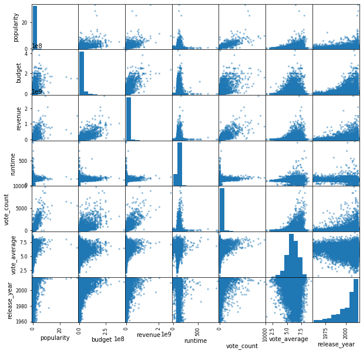

```python
# Plotting relationship between important numerical columns
df_ppal = df.drop(columns=["original_title", "cast", "director", "genres"], axis = 1)

pd.plotting.scatter_matrix(df_ppal, figsize=(10,10))
```

**Scatter matrix analysis**

1) It seems to be a relation between:

## Exploratory Data Analysis

### Question 1: Which genres are most popular from year to year?

To answer this question I will focus only on the most popular genre from year to year

```python
#Lets create an auxiliar dataframe with only the interested features

df_q1 = df.drop(columns=['popularity', 'budget', 'revenue', 'original_title', 'cast', 'director',
       'runtime', 'vote_count', 'vote_average'], axis=1)
df_q1.info()
```

```
<class 'pandas.core.frame.DataFrame'>
Int64Index: 10731 entries, 0 to 10865
Data columns (total 2 columns):
 #   Column        Non-Null Count  Dtype
---  ------        --------------  -----
 0   genres        10731 non-null  string
 1   release_year  10731 non-null  int64
dtypes: int64(1), string(1)
memory usage: 251.5 KB
```

```python
# Now, lets split every genres value in a list
df_q1["genres"] = df_q1["genres"].str.split('|') # https://stackoverflow.com/questions/14745022/how-to-split-a-dataframe-string-column-into-two-columns
# An alternative could be using:
#df = pd.concat([df, df["genres"].str.get_dummies(sep="|")], axis=1)
df_q1.head()
```

|  | genres | release_year |
| --- | --- | --- |
| 0 | [Action, Adventure, Science Fiction, Thriller] | 2015 |
| 1 | [Action, Adventure, Science Fiction, Thriller] | 2015 |
| 2 | [Adventure, Science Fiction, Thriller] | 2015 |
| 3 | [Action, Adventure, Science Fiction, Fantasy] | 2015 |
| 4 | [Action, Crime, Thriller] | 2015 |

```python
# Lets first create a list for all the possible values of a genre
genres_list = ["Action"]
for index, row in df_q1.iterrows():
    genres_list_row = row["genres"]
    row_len = len(genres_list_row)
    for genre in genres_list_row:
        if genre not in genres_list:
            genres_list.append(genre)
display(genres_list)
```

```
['Action',
 'Adventure',
 'Science Fiction',
 'Thriller',
 'Fantasy',
 'Crime',
 'Western',
 'Drama',
 'Family',
 'Animation',
 'Comedy',
 'Mystery',
 'Romance',
 'War',
 'History',
 'Music',
 'Horror',
 'Documentary',
 'TV Movie',
 'Foreign']
```

```python
# Lets now group by year
df_q1_grouped = df_q1.groupby("release_year").sum()
df_q1_grouped.head()
```

| release_year | genres |
| --- | --- |
| 1960 | [Drama, Horror, Thriller, Action, Adventure, W... |
| 1961 | [Adventure, Animation, Comedy, Family, Comedy,... |
| 1962 | [Adventure, Action, Thriller, Adventure, Drama... |
| 1963 | [Action, Thriller, Adventure, Animation, Famil... |
| 1964 | [Adventure, Action, Thriller, Drama, Comedy, W... |

```python
# Lets generate a dataframe with all the genres values for every year
# and then, lets add two columns: one for the max_count and the other for the max_genre
year_list = []
new_dict = {}
for index, row in df_q1_grouped.iterrows():
    year_list.append(index)
    genre_dict = {'Action':0, 'Adventure':0,'Science Fiction':0, 'Thriller':0,'Fantasy':0,'Crime':0,'Western':0,
                  'Drama':0,'Family':0, 'Animation':0,'Comedy':0, 'Mystery':0, 'Romance':0, 'War':0,'History':0,
                  'Music':0,'Horror':0,'Documentary':0,'TV Movie':0,'Foreign':0}
    for genre in genres_list:
        genre_dict[genre] = row["genres"].count(genre) #esta asignando el conteo con su genero por cada genero por cada año
        new_dict[index] = genre_dict

# Creating the dataframe
df_answer_q1 = pd.DataFrame.from_dict(data=new_dict, orient="index")
display(df_answer_q1.head())

# Get a series containing maximum value of each row
# For this, I used # https://thispointer.com/pandas-find-maximum-values-position-in-columns-or-rows-of-a-dataframe/#:~:text=Get%20maximum%20values%20of%20every%20row,with%20argument%20axis%3D1%20i.e.&text=It%20returned%20a%20series%20with%20row%20index,maximum%20value%20of%20each%20row.
max_count_genre = df_answer_q1.max(axis=1)
max_value_genre = df_answer_q1.idxmax(axis=1)

df_answer_q1["mp_count"] = max_count_genre
df_answer_q1["mp_value"] = max_value_genre

# Now, lets drop every genre column using genre_list
df_answer_q1 = df_answer_q1.drop(columns=genres_list)

#Lets check the new dataframe
df_answer_q1.head()
```

|  | Action | Adventure | Science Fiction | Thriller | Fantasy | Crime | Western | Drama | Family | Animation | Comedy | Mystery | Romance | War | History | Music | Horror | Documentary | TV Movie | Foreign |
| --- | --- | --- | --- | --- | --- | --- | --- | --- | --- | --- | --- | --- | --- | --- | --- | --- | --- | --- | --- | --- |
| 1960 | 8 | 5 | 3 | 6 | 2 | 2 | 6 | 13 | 3 | 0 | 8 | 0 | 6 | 2 | 5 | 1 | 7 | 0 | 0 | 1 |
| 1961 | 7 | 6 | 4 | 0 | 2 | 2 | 3 | 16 | 5 | 1 | 10 | 1 | 7 | 2 | 3 | 2 | 3 | 0 | 0 | 1 |
| 1962 | 8 | 7 | 2 | 7 | 1 | 3 | 3 | 21 | 2 | 0 | 5 | 4 | 5 | 3 | 4 | 1 | 5 | 0 | 0 | 1 |
| 1963 | 4 | 7 | 2 | 10 | 2 | 4 | 2 | 13 | 3 | 1 | 13 | 6 | 8 | 1 | 4 | 0 | 9 | 0 | 0 | 2 |
| 1964 | 5 | 5 | 4 | 9 | 4 | 10 | 1 | 20 | 4 | 2 | 16 | 4 | 9 | 3 | 3 | 5 | 6 | 0 | 0 | 1 |

|  | mp_count | mp_value |
| --- | --- | --- |
| 1960 | 13 | Drama |
| 1961 | 16 | Drama |
| 1962 | 21 | Drama |
| 1963 | 13 | Drama |
| 1964 | 20 | Drama |

### The answer

Finally, the most popular genre by year is:

```python
df_answer_q1.drop(columns=["mp_count"])
```

|  | mp_value |
| --- | --- |
| 1960 | Drama |
| 1961 | Drama |
| 1962 | Drama |
| 1963 | Drama |
| 1964 | Drama |
| 1965 | Drama |
| 1966 | Drama |
| 1967 | Comedy |
| 1968 | Drama |
| 1969 | Drama |
| 1970 | Drama |
| 1971 | Drama |
| 1972 | Drama |
| 1973 | Drama |
| 1974 | Drama |
| 1975 | Drama |
| 1976 | Drama |
| 1977 | Drama |
| 1978 | Drama |
| 1979 | Drama |
| 1980 | Drama |
| 1981 | Drama |
| 1982 | Drama |
| 1983 | Drama |
| 1984 | Drama |
| 1985 | Comedy |
| 1986 | Drama |
| 1987 | Comedy |
| 1988 | Comedy |
| 1989 | Comedy |
| 1990 | Drama |
| 1991 | Drama |
| 1992 | Drama |
| 1993 | Drama |
| 1994 | Comedy |
| 1995 | Drama |
| 1996 | Drama |
| 1997 | Drama |
| 1998 | Drama |
| 1999 | Drama |
| 2000 | Drama |
| 2001 | Comedy |
| 2002 | Drama |
| 2003 | Comedy |
| 2004 | Drama |
| 2005 | Drama |
| 2006 | Drama |
| 2007 | Drama |
| 2008 | Drama |
| 2009 | Drama |
| 2010 | Drama |
| 2011 | Drama |
| 2012 | Drama |
| 2013 | Drama |
| 2014 | Drama |
| 2015 | Drama |

We can see that "Drama" is the most popular genre almost for every year! except in 8 years that was replaced by "Comedy".

```
array([<matplotlib.axes._subplots.AxesSubplot object at 0x000001C44BA5E6C8>],
      dtype=object)
```

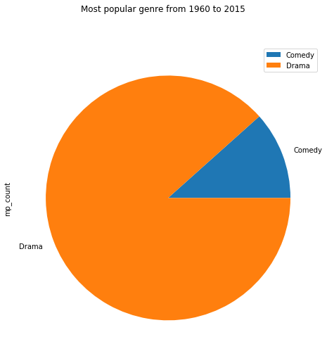

```python
df_answer_q1.groupby("mp_value").sum().plot(kind="pie", title="Most popular genre from 1960 to 2015", figsize = (8,8), subplots=True)
```

### Question 2: What kinds of properties are associated with movies that have high revenues?

Lets first categorize movies by revenue.

To do this, lets recall the revenue distribution

```
count    1.073100e+04
mean     4.031989e+07
std      1.176524e+08
min      0.000000e+00
25%      0.000000e+00
50%      0.000000e+00
75%      2.500000e+07
max      2.781506e+09
Name: revenue, dtype: float64
```

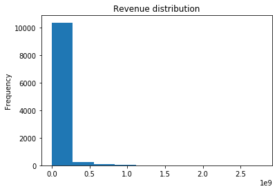

```python
display(df_ppal["revenue"].describe())
df_ppal["revenue"].plot(kind="hist", title="Revenue distribution", x="label")
```

As noted in the exploratory analysis, "revenue" is highly skewed right and the majority of movies have revenue of 0:

```python
print("The quantity of movies with no revenue is {}".format(df_ppal.query("revenue == 0").count()["revenue"]))

print("The quantity of movies with revenue distinct of 0 is {}".
      format(len(df_ppal["revenue"])-df_ppal.query("revenue == 0").count()["revenue"]))

print("The quantity of movies with revenue major than US$10 million is {}".
      format(df_ppal.query("revenue > 10e+06").count()["revenue"]))
```

```
The quantity of movies with no revenue is 5888
The quantity of movies with revenue distinct of 0 is 4843
The quantity of movies with revenue major than US$10 million is 3483
```

Lets create revenue categories

```python
# Creating a function to separate new categories
def make_revenue_ordinal(row):
    if row == 0:
        return "No revenue"
    if 0 < row <= 10e+05:
        return "Low revenue"
    if 10e+05 < row <= 10e+07:
        return "Medium revenue"
    if 10e+07 < row <= 10e+08:
        return "High revenue"
    if 10e+08 < row <= 2.781506e+09:
        return "Very high  revenue"
```

```python
# Lets call the function as an object
df_ppal_bkp = df_ppal
df_ppal["revenue_ordinal"] = df_ppal["revenue"].apply(make_revenue_ordinal)
df_ppal.head(1)
```

|  | popularity | budget | revenue | runtime | vote_count | vote_average | release_year | revenue_ordinal |
| --- | --- | --- | --- | --- | --- | --- | --- | --- |
| 0 | 32.985763 | 150000000 | 1513528810 | 124 | 5562 | 6.5 | 2015 | Very high revenue |

```
array([<matplotlib.axes._subplots.AxesSubplot object at 0x000001C44BB10148>],
      dtype=object)
```

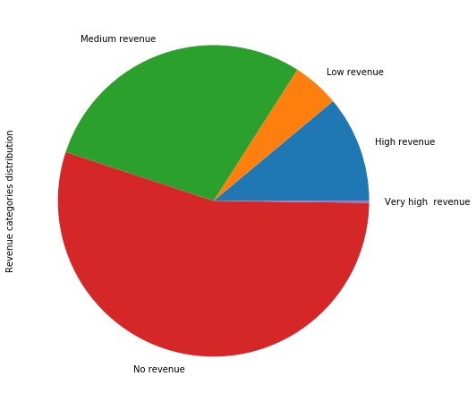

```python
# Lets see how every category is distributed
df_ppal.groupby("revenue_ordinal")["revenue"].count().plot(kind="pie", subplots=True, figsize = (8,8), label="Revenue categories distribution")
```

Now, we can create a new dataframe including only the category that has "High revenue" values

```python
df_ppal_h_r = df_ppal[df_ppal["revenue_ordinal"] == "High revenue"]
df_ppal_h_r.describe()
```

|  | popularity | budget | revenue | runtime | vote_count | vote_average | release_year |
| --- | --- | --- | --- | --- | --- | --- | --- |
| count | 1187.000000 | 1.187000e+03 | 1.187000e+03 | 1187.000000 | 1187.000000 | 1187.000000 | 1187.000000 |
| mean | 2.019626 | 6.827904e+07 | 2.588027e+08 | 114.907329 | 1114.453243 | 6.362763 | 2002.939343 |
| std | 1.897761 | 5.125724e+07 | 1.798322e+08 | 26.654681 | 1132.996380 | 0.704583 | 9.706295 |
| min | 0.131526 | 0.000000e+00 | 1.000201e+08 | 72.000000 | 10.000000 | 4.200000 | 1961.000000 |
| 25% | 1.011866 | 3.000000e+07 | 1.348740e+08 | 99.000000 | 348.000000 | 5.900000 | 1998.000000 |
| 50% | 1.540322 | 5.600000e+07 | 1.902135e+08 | 112.000000 | 719.000000 | 6.300000 | 2005.000000 |
| 75% | 2.440650 | 9.200000e+07 | 3.138602e+08 | 127.000000 | 1433.500000 | 6.900000 | 2011.000000 |
| max | 28.419936 | 3.000000e+08 | 9.764756e+08 | 705.000000 | 9767.000000 | 8.300000 | 2015.000000 |

Lets analyze the distribution and the correlation between revenue and the other features

```
array([[<matplotlib.axes._subplots.AxesSubplot object at 0x000001C44BB2EEC8>,
      dtype=object)
```

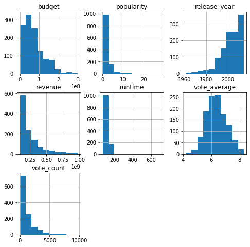

```python
df_ppal_h_r.hist(figsize=(8,8))
```

```
array([[<matplotlib.axes._subplots.AxesSubplot object at 0x000001C44CE57F08>,
      dtype=object)
```

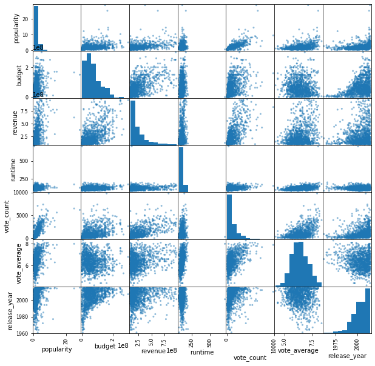

```python
pd.plotting.scatter_matrix(df_ppal_h_r, figsize=(10,10))
```

### Question 3: Is there any relationship between popularity and budget?

Lets start by recalling the scatterplot between this two features

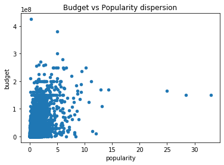

```python
df_ppal.plot.scatter(x="popularity", y="budget", title="Budget vs Popularity dispersion")
```

It seems that there is a positive relationship between these features, but there is a lot of dispersion.

Lets narrow the analysis considering only values of popularity below 4:

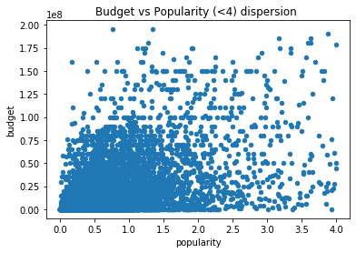

```python
df_q3 = df_ppal[df_ppal["popularity"] < 4]
df_q3 = df_q3[df_q3["budget"] < 2e+08]
df_q3.plot.scatter(x="popularity", y="budget", title="Budget vs Popularity (<4) dispersion ")
```

```python
# It still shows high variability, so lets recall the revenue categorization and lets apply the same for budget feature

def make_budget_ordinal(row):
    if row == 0:
        return "No budget"
    if 0 < row <= 10e+05:
        return "Low budget"
    if 10e+05 < row <= 10e+06:
        return "Medium budget"
    if 10e+06 < row <= 10e+07:
        return "High budget"
    if 10e+07 < row <= 4.250000e+08:
        return "Very high  budget"
    else:
        return "?"

df_ppal["budget_ordinal"] = df_ppal["budget"].apply(make_budget_ordinal)

#display(df_ppal.head(1))

#lets group by budget_ordinal and only show popularity column

display(df_ppal.groupby("budget_ordinal").mean()["popularity"])
```

```
budget_ordinal
High budget          1.067809
Low budget           0.369895
Medium budget        0.587810
No budget            0.336389
Very high  budget    3.300546
Name: popularity, dtype: float64
```

### Answer to the third question

As we can see in the popularity column, the high and very high budget have both major than 1 of popularity, these values are major than the other categories by far!!

So, it seems that efectively there is a relationship. If budget is high or very high, your movie will be most popular than if your budget is poorer, at least in mean terms.

|  | popularity | budget | revenue | runtime | vote_count | vote_average | release_year | revenue_ordinal | budget_ordinal | v_a_ordinal |
| --- | --- | --- | --- | --- | --- | --- | --- | --- | --- | --- |
| 30 | 3.927333 | 0 | 29355203 | 103 | 425 | 6.4 | 2015 | Medium revenue | No budget | Medium vote |

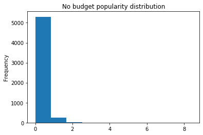

```python
# Lets check that the popularity distribution for every budget category is the same

df_ppal_n_b = df_ppal[df_ppal["budget_ordinal"] == "No budget"]
display(df_ppal_n_b.head(1))
df_ppal_n_b["popularity"]. plot(kind="hist", title="No budget popularity distribution")
```

|  | popularity | budget | revenue | runtime | vote_count | vote_average | release_year | revenue_ordinal | budget_ordinal | v_a_ordinal |
| --- | --- | --- | --- | --- | --- | --- | --- | --- | --- | --- |
| 113 | 1.40805 | 700000 | 17986781 | 103 | 448 | 7.3 | 2015 | Medium revenue | Low budget | High vote |

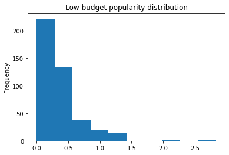

```python
df_ppal_l_b = df_ppal[df_ppal["budget_ordinal"] == "Low budget"]
display(df_ppal_l_b.head(1))
df_ppal_l_b["popularity"]. plot(kind="hist", title="Low budget popularity distribution")
```

|  | popularity | budget | revenue | runtime | vote_count | vote_average | release_year | revenue_ordinal | budget_ordinal | v_a_ordinal |
| --- | --- | --- | --- | --- | --- | --- | --- | --- | --- | --- |
| 35 | 3.557846 | 6000000 | 35401758 | 117 | 1520 | 8.0 | 2015 | Medium revenue | Medium budget | High vote |

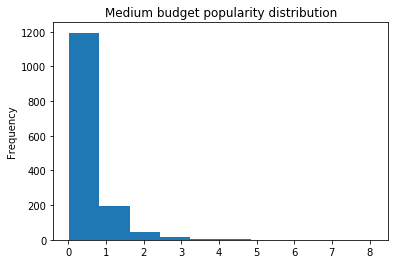

```python
df_ppal_m_b = df_ppal[df_ppal["budget_ordinal"] == "Medium budget"]
display(df_ppal_m_b.head(1))
df_ppal_m_b["popularity"]. plot(kind="hist", title="Medium budget popularity distribution")
```

|  | popularity | budget | revenue | runtime | vote_count | vote_average | release_year | revenue_ordinal | budget_ordinal | v_a_ordinal |
| --- | --- | --- | --- | --- | --- | --- | --- | --- | --- | --- |
| 8 | 7.404165 | 74000000 | 1156730962 | 91 | 2893 | 6.5 | 2015 | Very high revenue | High budget | Medium vote |

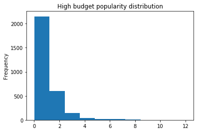

```python
df_ppal_h_b = df_ppal[df_ppal["budget_ordinal"] == "High budget"]
display(df_ppal_h_b.head(1))
df_ppal_h_b["popularity"]. plot(kind="hist", title="High budget popularity distribution")
```

|  | popularity | budget | revenue | runtime | vote_count | vote_average | release_year | revenue_ordinal | budget_ordinal | v_a_ordinal |
| --- | --- | --- | --- | --- | --- | --- | --- | --- | --- | --- |
| 0 | 32.985763 | 150000000 | 1513528810 | 124 | 5562 | 6.5 | 2015 | Very high revenue | Very high budget | Medium vote |

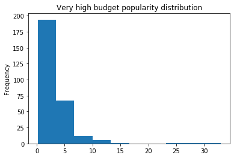

```python
df_ppal_vh_b = df_ppal[df_ppal["budget_ordinal"] == "Very high  budget"]
display(df_ppal_vh_b.head(1))
df_ppal_vh_b["popularity"]. plot(kind="hist", title="Very high budget popularity distribution")
```

If your movie have low or none budget, then is highly improbable that will be a popular movie!!

### Question 4: What kinds of properties are associated with movies that have high vote?

In order to answer this question, lets create categories for movies votes

```
9.2      1
8.8      1
8.7      1
8.5      4
8.4      8
8.3      9
8.2      5
8.1     15
8.0     34
7.9     44
7.8     56
7.7     59
7.6     82
7.5    115
7.4    133
7.3    186
7.2    213
7.1    263
7.0    271
6.9    307
6.8    321
6.7    368
6.6    409
6.5    452
6.4    444
6.3    457
6.2    463
6.1    491
6.0    487
5.9    469
5.8    482
5.7    414
5.6    411
5.5    380
5.4    336
5.3    355
5.2    299
5.1    254
5.0    214
4.9    205
```

[output cut: 16 more lines]

```
3.2      9
3.1     13
3.0      9
2.9      9
2.8      7
2.7      3
2.6      3
2.5      2
2.4      7
2.3      2
2.2      3
2.1      3
2.0      1
1.5      2
Name: vote_average, dtype: int64
```

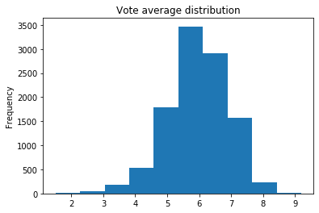

```python
# To do this, lets first see how the vote_average values are distributed
display(df_ppal["vote_average"].value_counts().sort_index(ascending=False))
df_ppal["vote_average"].plot(kind="hist", title="Vote average distribution")
```

There is a concentration of the frequency of vote_average between 2.8 and 8.4

```python
# Lets use "describe" to separate votes in caterogies
df_ppal.describe()["vote_average"].iloc[3:7]
#df_ppal.describe()
```

```
min    1.5
25%    5.4
50%    6.0
75%    6.6
Name: vote_average, dtype: float64
```

```python
#Alternative 1: segment with a function
##def make_votes_ordinal(row):
##    if 1.5 <= row < 5.4:
##        return "Poor votes"
##    if 5.4 <= row <= 6:
##        return "Low votes"
##    if 6 < row <= 6.6:
##        return "Medium vote"
##    if 6.6 < row <= 9.2:
##        return "High vote"
##   else:
##        return "?"
#df_ppal["v_a_ordinal"] = df_ppal["vote_average"].apply(make_votes_ordinal)

# Alternative 2: segment with cut function as seen on https://pandas.pydata.org/pandas-docs/stable/reference/api/pandas.cut.html
v_a_bins = [1.4, 5.4, 6, 6.6, 9.3]
v_a_bins_labels = ["Poor votes", "Low votes", "Medium vote", "High vote"]
df_ppal["v_a_ordinal"] = pd.cut(df_ppal["vote_average"], bins=v_a_bins,
                                labels=v_a_bins_labels)
df_ppal.head(1)
df_ppal["v_a_ordinal"].value_counts()
display(df_ppal.info())
```

```
<class 'pandas.core.frame.DataFrame'>
Int64Index: 10731 entries, 0 to 10865
Data columns (total 10 columns):
 #   Column           Non-Null Count  Dtype
---  ------           --------------  -----
 0   popularity       10731 non-null  float64
 1   budget           10731 non-null  int64
 2   revenue          10731 non-null  int64
 3   runtime          10731 non-null  int64
 4   vote_count       10731 non-null  int64
 5   vote_average     10731 non-null  float64
 6   release_year     10731 non-null  int64
 7   revenue_ordinal  10731 non-null  object
 8   budget_ordinal   10731 non-null  object
 9   v_a_ordinal      10731 non-null  category
dtypes: category(1), float64(2), int64(5), object(2)
memory usage: 1.1+ MB
```

```
None
```

```python
# Lets groupby v_a_ordinal and see the mean
df_ppal.groupby("v_a_ordinal").mean()
```

| v_a_ordinal | popularity | budget | revenue | runtime | vote_count | vote_average | release_year |
| --- | --- | --- | --- | --- | --- | --- | --- |
| Poor votes | 0.421180 | 1.040083e+07 | 1.309802e+07 | 95.397079 | 67.876912 | 4.791134 | 2004.014951 |
| Low votes | 0.558444 | 1.566318e+07 | 3.500932e+07 | 101.082104 | 145.362467 | 5.764699 | 2001.200151 |
| Medium vote | 0.710304 | 1.761309e+07 | 5.025296e+07 | 105.453976 | 238.417526 | 6.341605 | 1999.900957 |
| High vote | 0.956228 | 1.590955e+07 | 6.650086e+07 | 108.837340 | 453.471154 | 7.118630 | 1999.626202 |

### Answer to question 4

In the last table, we can see that:

- High average vote movies are slightly more popular than movies with low average votes
- There are slight differences in budget mean per every average vote category. A higher vote is not neccesary movies with better budget
- Movies with higher votes get, in the mean, most revenues. The high average vote category in fact is the category with most revenue

[output not shown]

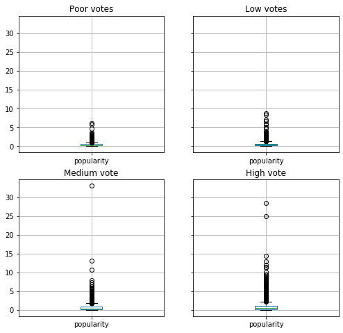

```python
# Lets see the popularity and revenues relationship with high votes, just in case that the mean computed in the last table
# does not held enough information
df_ppal.groupby("v_a_ordinal").boxplot(column=["popularity"], figsize=(8,8))
display(df_ppal_plot.head(1))
```

We could remove popularity values to see only dispersed cases to see more clearly this phenomenah:

```
<class 'pandas.core.frame.DataFrame'>
Int64Index: 567 entries, 0 to 10594
Data columns (total 10 columns):
 #   Column           Non-Null Count  Dtype
---  ------           --------------  -----
 0   popularity       567 non-null    float64
 1   budget           567 non-null    int64
 2   revenue          567 non-null    int64
 3   runtime          567 non-null    int64
 4   vote_count       567 non-null    int64
 5   vote_average     567 non-null    float64
 6   release_year     567 non-null    int64
 7   revenue_ordinal  567 non-null    object
 8   budget_ordinal   567 non-null    object
 9   v_a_ordinal      567 non-null    category
dtypes: category(1), float64(2), int64(5), object(2)
memory usage: 45.0+ KB
```

```
Poor votes          AxesSubplot(0.1,0.559091;0.363636x0.340909)
Low votes      AxesSubplot(0.536364,0.559091;0.363636x0.340909)
Medium vote             AxesSubplot(0.1,0.15;0.363636x0.340909)
High vote          AxesSubplot(0.536364,0.15;0.363636x0.340909)
dtype: object
```

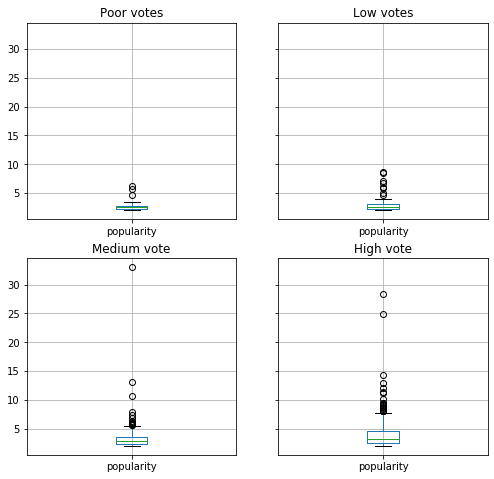

```python
df_ppal_va_ordinal = df_ppal[df_ppal.popularity > 2]
df_ppal_va_ordinal.info()
df_ppal_va_ordinal.groupby("v_a_ordinal").boxplot(column=["popularity"], figsize=(8,8))
```

[output not shown]

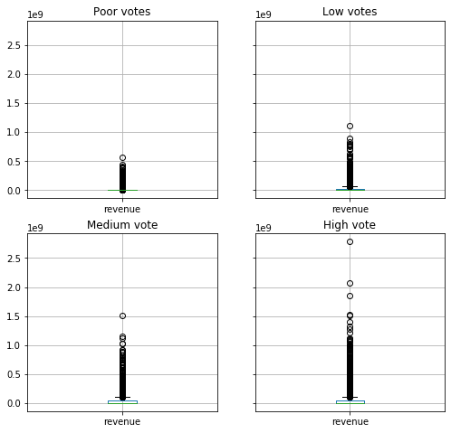

```python
# Lets do the same with revenues
df_ppal.groupby("v_a_ordinal").boxplot(column=["revenue"], figsize=(8,8))
display(df_ppal_plot.head(1))
```

As we saw in popularity case, High votes category reach major revenue values

## Conclusions

**Principal conclusions**

**From Data Wrangling section**

- Over the 50% of the "budget" and "revenue" values are 0 and there are values between 1 and 100 dollars. All of these insights seems like this data is wrongly placed. I just checked a couple of films budgets in wikipedia and the budget did not match with the "0" values in the TMDb.
- I tried to categorize correctily movies between films, tv series, docummentary, mini series looking "runtime" feature ranges, but there were always a movie too long that could be considered a tv-serie and a documentary too short that could be considered a film.
- "vote_count" effectively were biased by the movie release_year. This can be noted looking at the scatter plots in this section (the most recent release_year, the higher the vote_counts. This behaviour could not be observed in "vote_average" feature.

**From the exploratory analysis section**

- Since budget, revenue, votes_average and popularity features are numerical, and the first two presented a histogram highly skewed right, I had to categorize them. Only votes_average presented almost a normal distribution so the quartiles limits were used to make the bins.
- Surprisingly, the most popular movies genre almost every year is "Drama". I personally believed that "Science Fiction" could be a strong candidate.
- High revenue movies have also high budget, and better vote average than movies with lower revenues.
- High budget movies are more popular than lower budget movies
- Higher votes movies are more likely to reach major revenues (there are mor movies that have higher revenues in "high vote" category)

**Final thoughts**

Categorization allowed me to bring more insightful conclusions to numerical data. Groupby allowed me to separate the analysis per efery categorization group and matplotlib helped me with the visualization of the behaviour of this categories and their relationships.

To improve the quality of the data, I would recommend to scrap other movie databases webpage (even Wikipedia has helpful) information, specially budget and revenue features.

To finish this report I would like to thank Udacity for making this awesome course and such a guided detail that was really helpful.